# Bootstrapping Evaluation

We now want to evaluate the robusticity of our main core microbiome calculations against the bootstrapped versions.

```r
library(tidyverse)
```

Now we need to load the corresponding tables of interest. We will only analyse the `nt` version as this is our main analysis table.

```r
bs_genus_wcontrols <- read_tsv("../04-analysis/screening/presenceabsence_intersection.backup/99-coremicrobiome_presenceabsence_pergroup_bootstrapped_complete_nt_0.07_fracinds0.5_fracpops0.66_singleindpopsdroppedFALSE_includecontrolsTRUE_bootstraps1000_hostgenus_genus_20200924.tsv", col_types = cols()) %>% mutate(Level = "genus", Controls = T)
bs_genus_nocontrols <- read_tsv("../04-analysis/screening/presenceabsence_intersection.backup/99-coremicrobiome_presenceabsence_pergroup_bootstrapped_complete_nt_0.07_fracinds0.5_fracpops0.66_singleindpopsdroppedFALSE_includecontrolsFALSE_bootstraps1000_hostgenus_genus_20200924.tsv", col_types = cols()) %>% mutate(Level = "genus", Controls = F)

bs_species_wcontrols <- read_tsv("../04-analysis/screening/presenceabsence_intersection.backup/99-coremicrobiome_presenceabsence_pergroup_bootstrapped_complete_nt_0.04_fracinds0.5_fracpops0.66_singleindpopsdroppedFALSE_includecontrolsTRUE_bootstraps1000_hostgenus_species_20200924.tsv", col_types = cols()) %>% mutate(Level = "species", Controls = T)
bs_species_nocontrols <- read_tsv("../04-analysis/screening/presenceabsence_intersection.backup/99-coremicrobiome_presenceabsence_pergroup_bootstrapped_complete_nt_0.04_fracinds0.5_fracpops0.66_singleindpopsdroppedFALSE_includecontrolsFALSE_bootstraps1000_hostgenus_species_20200924.tsv", col_types = cols()) %>% mutate(Level = "species", Controls = F)

bs_all_wcontrols <- bind_rows(bs_genus_wcontrols, bs_species_wcontrols) %>% mutate(Taxon = gsub(" ", "_", Taxon))
bs_all_nocontrols <- bind_rows(bs_genus_nocontrols, bs_species_nocontrols) %>% mutate(Taxon = gsub(" ", "_", Taxon))
```

We also want to upload the originally calculated core microbiome(s).

```r
org_genus <- read_tsv("../04-analysis/screening/presenceabsence_intersection.backup/08a-coremicrobiome_presenceabsence_upsettable_allsoftware_maltdbnt_0.07_fracinds0.5_fracpops0.66_singleindpopsdroppedF_hostgenus_genus_20190902.tsv", col_types = cols()) %>% mutate(Level = "genus")
org_species <- read_tsv("../04-analysis/screening/presenceabsence_intersection.backup/08b-coremicrobiome_presenceabsence_upsettable_allsoftware_maltdbnt_0.04_fracinds0.5_fracpops0.66_singleindpopsdroppedF_hostgenus_species_20190902.tsv", col_types = cols()) %>% mutate(Level = "species")

org_all <- bind_rows(org_genus, org_species) %>% select(Combination, Taxon)
```

In the main figure/analysis, we are further interested in the following combinations

```r
anthropoid <- c("Actinomyces", "Campylobacter", "Capnocytophaga",
"Corynebacterium", "Fusobacterium", "Ottowia", "Prevotella",
"Pseudopropionibacterium", "Selenomonas", "Streptococcus")

hominid <- c("Fretibacterium", "Olsenella", "Tannerella")

hominin <- c("Desulfomicrobium", "Mogibacterium", "Parvimonas", "Porphyromonas",
"Treponema")

homo <- c("Treponema")


other <- c("Aggregatibacter", "Anaerolineaceae_bacterium_oral_taxon_439",
"Eikenella", "Filifactor_alocis", "Gemella_sp._oral_taxon_928", "Leptotrichia",
"Neisseria", "Veillonella")
```

## Filtering

To filter to tables of the original microbial taxa of interest

```r
bs_all_wcontrols_filt <- left_join(org_all, bs_all_wcontrols) %>% filter(Taxon %in% c(anthropoid, hominid, hominin, homo, other))
bs_all_nocontrols_filt <- left_join(org_all, bs_all_nocontrols) %>% filter(Taxon %in% c(anthropoid, hominid, hominin, homo, other))
```

And then to get the highest scoring combination (out of the bootstrap replicates).

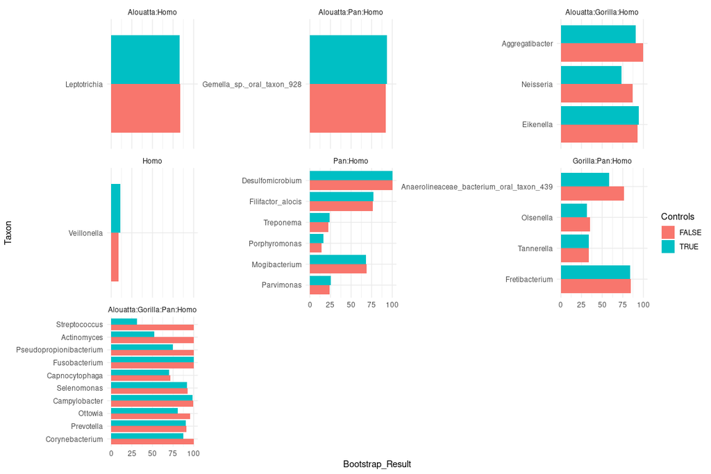

```r
bs_all_wcontrols_filt_max <- bs_all_wcontrols_filt %>% group_by(Taxon) %>% filter(Bootstrap_Result == max(Bootstrap_Result)) %>% select(Combination, Taxon, Bootstrap_Result) %>% mutate(Controls = T)
bs_all_nocontrols_filt_max <- bs_all_nocontrols_filt %>% group_by(Taxon) %>% filter(Bootstrap_Result == max(Bootstrap_Result)) %>% select(Combination, Taxon, Bootstrap_Result) %>% mutate(Controls = F)

comparison <- bind_rows(bs_all_wcontrols_filt_max, bs_all_nocontrols_filt_max) %>% mutate(Combination = factor(Combination, levels = rev(comb_order))) %>% arrange(Combination, rev(Bootstrap_Result))

comparison <- comparison %>% mutate(Taxon = factor(Taxon, levels = comparison$Taxon %>% unique))

ggplot(comparison, aes(Taxon, Bootstrap_Result, fill = Controls, group = Controls)) + geom_bar(stat = "identity", position = "dodge") + coord_flip() + theme_minimal() + facet_wrap(~Combination, scales = "free_y")
```

My interpretation is that generally that the differences in including/removing controls isn’t so big other than for the really diverse genera (*Streptococcus*, *Actinomyces*), which could be generally explained by during bootstrapping more skin contaminated controls get in that particular replicate. Controls are the largest group (35) which may also explain why these ‘re-assignments’ happen more often.

However when looking at the actual boostrap values e.g. for the without-controls dataset; while the ‘Anthropoid’ combination is relatively robust, when we go down to small combinations, percentage bootstraps become more very low (e.g. Tannerella). This maybe because this derived from low prevalence within all host genera (e.g. signals only become strong enough in that combination depending on how many ‘mature calculus’ individuals are picked up in that replicate; with the assumption the red complex taxa appear to have stronger signals in more mature calculus).

We can maybe look at this by seeing how many alternative combinations each taxon has assigned.

For example for with controls

```r
bs_all_wcontrols_combdiv <- bs_all_wcontrols %>% group_by(Taxon) %>% summarise(n = n(), paste0(Combination, collapse = "|")) %>% mutate(Controls = T)
bs_all_nocontrols_combdiv <- bs_all_nocontrols %>% group_by(Taxon) %>% summarise(n = n(), paste0(Combination, collapse = "|")) %>% mutate(Controls = F)
bs_all_both_combdiv <- bind_rows(bs_all_wcontrols_combdiv, bs_all_nocontrols_combdiv)

## Join with main bootstrap data

comparison <- left_join(comparison, bs_all_both_combdiv)
```

How does the diversity of the number of possible combinations found during bootstrap compare to the bootstrap values themsleves?

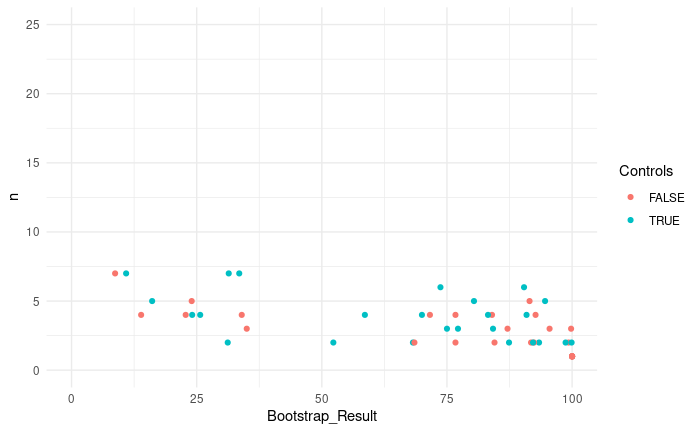

```r
ggplot(comparison, aes(Bootstrap_Result, n, colour = Controls)) +
  geom_point() +
  theme_minimal() +
  ylim(0, 25) +
  xlim(0, 100)
```

We can see a very slight trend that the lower the bootstrap value, the higher the number of combinations occur.

However lets see how this corresponds to our bar plot of bootstrap value of the taxa of interest.

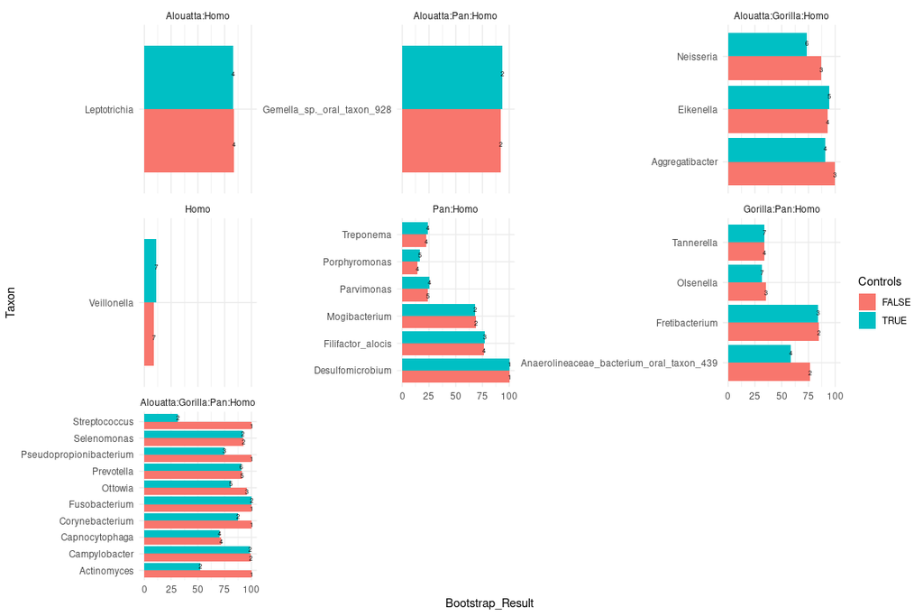